# Data Processing

# Data preparation for Logistic Regression

- Correlation heatmap

```python
#plt.figure(figsize=(18, 12))
#sns.heatmap(df.corr(), annot=True, cmap='YlOrRd')
#plt.show()
```

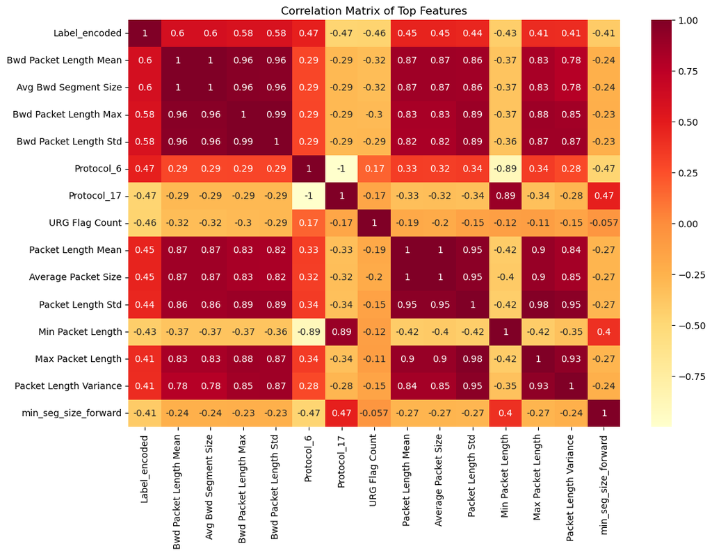

```python
corr_matrix = df_dummies.corr().abs()
top_features = corr_matrix['Label_encoded'].sort_values(ascending=False).head(15).index
top_corr = df_dummies[top_features].corr()

plt.figure(figsize=(12, 8))
sns.heatmap(top_corr, annot=True, cmap='YlOrRd')
plt.title("Correlation Matrix of Top Features")
plt.show()
```

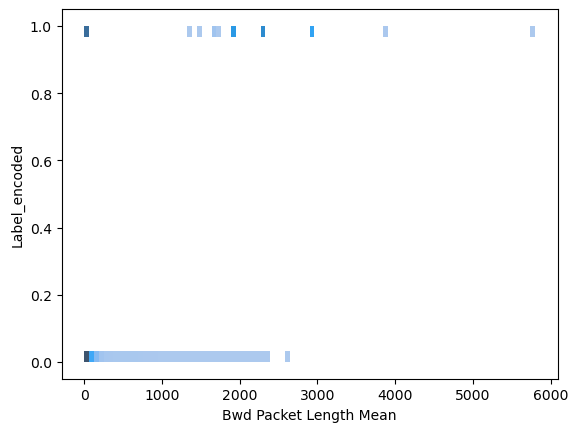

```python
sns.histplot(data = df_dummies , x ='Bwd Packet Length Mean',y = 'Label_encoded')
#sns.histplot(data = df , x ='Bwd Packet Length Std',y = 'Label_encoded')
#sns.histplot(data = df , x ='Bwd Packet Length Max',y = 'Label_encoded')
#sns.histplot(data = df , x ='Avg Bwd Segment Size',y = 'Label_encoded')
```

1. Split the data into features (X) and target (y):

```python
X = df.drop(['Label_encoded'], axis=1)
y = df['Label_encoded']
```

1. Handle categorical variables based on highest correlation

```python
X = df_dummies[['Bwd Packet Length Mean', 'Avg Bwd Segment Size']]
```

1. Use StandardScaler from sklearn to transform the x dataframe.

```python
from sklearn.preprocessing import StandardScaler
scaler = StandardScaler()
X_scaled = scaler.fit_transform(X)
```

1. Split dataset into train and test data use train_test_split with test_size = 0.2 and random_state = 42

```python
from sklearn.model_selection import train_test_split
X_train, X_test, y_train, y_test = train_test_split(X_scaled, y, test_size=0.2, random_state=42)
```

# Classification Model 1: Logistic Regression

1. Create a logistic regression model using sklearn
2. Fit the model with the train data
3. Get the score from the model using test data
4. Plot confusion matrix using [ConfusionMatrixDisplay]

```python
from sklearn.metrics import ConfusionMatrixDisplay
import matplotlib.pyplot as plt

# Create a logistic regression model using sklearn library
clf=LogisticRegression()
clf.fit(X_train,y_train)

#print score for test data
print(clf.score(X_test,y_test))
```

```
0.7649781833484685
```

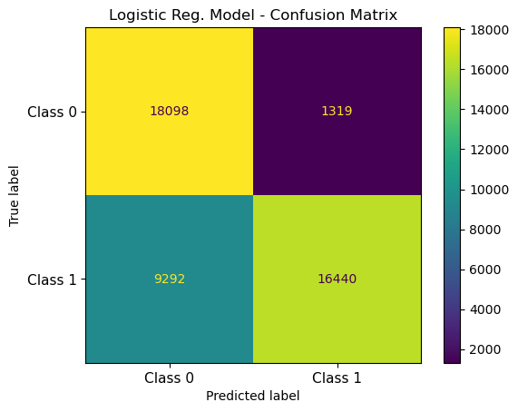

```python
from sklearn.metrics import ConfusionMatrixDisplay

cm = ConfusionMatrixDisplay.from_estimator(clf,X_test, y_test)
#plt.figure()
#plot_confusion_matrix(cm, figsize=(12,8), hide_ticks=True, cmap=plt.cm.Blues)
plt.title("Logistic Reg. Model - Confusion Matrix")
plt.xticks(range(2), ["Class 0","Class 1"], fontsize=11)
plt.yticks(range(2), ["Class 0","Class 1"], fontsize=11)
plt.show()
```

Evaluating the Model

```python
y_pred = clf.predict(X_test)

from sklearn.metrics import accuracy_score
accuracy = accuracy_score(y_test, y_pred)
print(f'Accuracy: {accuracy:.2f}')
```

```
Accuracy: 0.76
```